# RShiny: Basics and User Interface

Justin Post

## Big picture

- Know how to read data in, combine and manipulate it, summarize, and visualize
  - `tidyverse` great!
- Know how to do some predictive modeling
  - `caret` is awesome
- Know how to collaborate and communicate code/results
  - via github and `rmarkdown`
- Ready to create interactive web applets or dashboards!
  - Great way to present your data and results for others

## What is R Shiny?

- [R Shiny Package](http://shiny.rstudio.com/)
  - Developed by RStudio
  - Allows for creation of apps and dashboards
- A .R file (or two) with special code to create an app
  - `ui.R` (User Interface)
  - `server.R` (R functions that run/respond to UI)
  - `app.R` (both UI and server combined)
- Requires no HTML, CSS, or JavaScript!

## Example App

Number of bins:

20

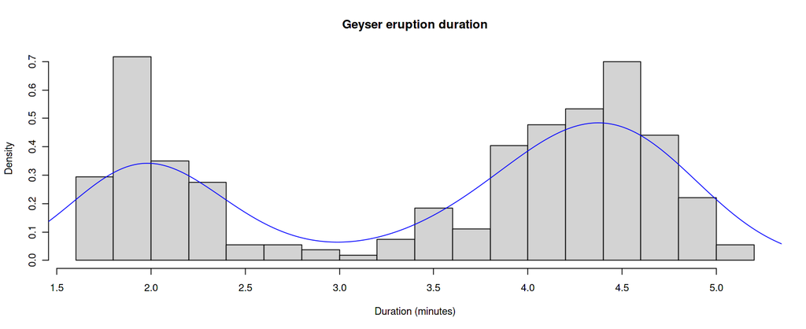

## How to Develop R Shiny Apps

- Explore online repositories/resources for existing apps
  - Learn capabilities!
- Learn how to create the user interface (UI)
- Understand how the server (R) backend works
- Customize apps
- Learn solutions to common issues when creating apps and deploy it

## Available Apps

- Many available resources!!
- [Shiny Gallery/Showcase](https://shiny.rstudio.com/gallery/)
- [Stat Concepts](https://github.com/gastonstat/shiny-introstats/)
- [More Stat Concepts](https://www.researchgate.net/publication/298786680_Web_Application_Teaching_Tools_for_Statistics_Using_R_and_Shiny)
- [Even more!](http://www.statistics.calpoly.edu/shiny)
- Take a few minutes to explore some apps if you haven't already!

## Elements of an App

- Each app has two things
  - User Interface (UI)
  - Server

## Elements of an App

- Each app has two things
  - User Interface (UI)
  - Server
- UI determines **layout** of app
  - Sets up widgets (items users can interact with)

## Elements of an App

- Each app has two things
  - User Interface (UI)
  - Server
- UI determines **layout** of app
  - Sets up widgets (items users can interact with)
- Server contains R code to **run for the app**
  - Can include plots, model fitting, any R code really…

## Elements of an App

- Each app has two things
  - User Interface (UI)
  - Server
- UI determines **layout** of app
  - Sets up widgets (items users can interact with)
- Server contains R code to **run for the app**
  - Can include plots, model fitting, any R code really…
- Can do with single file (`app.R`) but we'll use a separate file (`ui.R` and `server.R`)

## Two File Approach

- Create folder for each App you create
- Each App's folder should have `ui.R` and `server.R` files
- (If single file, `app.R` in each folder)

[figure not shown]

## `ui.R` Basic Layout

```r
library(shiny)

ui <- fluidPage(
    titlePanel(),

  sidebarLayout(
    sidebarPanel(#usually widgets
      ),
    mainPanel(#usually output
      )
  )
)
```

## UI Common Layout

## title panel

sidebar panel  
|  
|  
|  
|  
|  
|  
V  
Usually User Inputs

main panel content-------------------->  
|  
|  
|  
| Usually Output  
| that Reacts to User Input  
|  
V

## `server.R` Basic File

```r
library(shiny)

shinyServer(function(input, output, session) {

})
```

## Shiny Templates

Readily available in R studio

[figure not shown]

## Two File Template

```r
library(shiny)
ui <- fluidPage(
   # Application title
   titlePanel("Old Faithful Geyser Data"),
   # Sidebar with a slider input for number of bins
   sidebarLayout(
      sidebarPanel(
         sliderInput("bins",
                     "Number of bins:",
                     min = 1,
                     max = 50,
                     value = 30)
      ),
      # Show a plot of the generated distribution
      mainPanel(
         plotOutput("distPlot")
      )
   )
)
```

## Two File Template

```r
library(shiny)

# Define server logic required to draw a histogram
server <- function(input, output) {
   output$distPlot <- renderPlot({
      # generate bins based on input$bins from ui.R
      x    <- faithful[, 2]
      bins <- seq(min(x), max(x), length.out = input$bins + 1)

      # draw the histogram with the specified number of bins
      hist(x, breaks = bins, col = 'darkgray', border = 'white')
   })
}
```

## Running an App

- While `ui.R` or `server.R` is your active window, click the **Run App** button

[figure not shown]

## Running an App

- While `ui.R` or `server.R` is your active window, click the **Run App** button

[figure not shown]

- Use `shiny::runApp()` function
  - ex: `runApp("path/to/ui_or_server_or_app.R")`

## Running an App

- While `ui.R` or `server.R` is your active window, click the **Run App** button

[figure not shown]

- Use `shiny::runApp()` function
  - ex: `runApp("path/to/ui_or_server_or_app.R")`
- Running App will tie up R console!
- End by hitting Esc or closing shiny app
- Take a minute and run the template app

## Adding to the UI

Using a comma to separate items, you can add

- Any plain strings
- Widgets
- Formatted text (using HTML type functions)

[figure not shown]

- Output from things created in the `server.R` file

## Adding to the UI - Widgets

- Widgets can be added using their `*Input` functions
- Separate widgets (and other items) by commas in ui.R file

## Adding to the UI - Widgets

- Widgets can be added using their `*Input` functions
- Separate widgets (and other items) by commas in ui.R file

[figure not shown]

[interactive chart not shown]

## HTML tags

Adding Formatted Text via HTML

[output not shown]

```r
names(shiny::tags)
```

```
##   [1] "a"                   "abbr"                "address"
##   [4] "animate"             "animateMotion"       "animateTransform"
##   [7] "area"                "article"             "aside"
##  [10] "audio"               "b"                   "base"
##  [13] "bdi"                 "bdo"                 "blockquote"
##  [16] "body"                "br"                  "button"
##  [19] "canvas"              "caption"             "circle"
##  [22] "cite"                "clipPath"            "code"
##  [25] "col"                 "colgroup"            "color-profile"
##  [28] "command"             "data"                "datalist"
##  [31] "dd"                  "defs"                "del"
##  [34] "desc"                "details"             "dfn"
##  [37] "dialog"              "discard"             "div"
##  [40] "dl"                  "dt"                  "ellipse"
##  [43] "em"                  "embed"               "eventsource"
```

[output cut: 46 more lines]

## Sharing Between Server and UI

- Widgets are used to take input from the user
- Use their values in `server.R` (has your analysis or vis code!)
- Functions in `server.R` will create output to go in the `ui.R`

## Sharing Between Server and UI

[figure not shown]

## Adding to the UI - Example Syntax

```r
library(shiny)
ui <- fluidPage(
  sidebarLayout(
    sidebarPanel(
      h2("Widgets/Text"),
      numericInput("NI",label="Intercept",value=10),
      sliderInput("SI",label="Slope",min=-1,max=1,value=0,step=0.1),
      "More text",
      br(),
      a(href="http://www.rstudio.com",target="_blank","Link to RStudio")
    ),
    mainPanel(plotOutput("dataPlot"), #dataPlot is name of "plot" object in server
              textOutput("dataInfo"), #dataInfo is name of "text" object in server
              dataTableOutput("dataTable") #dataTable is name of "data" object in server
    )
  )
)
```

[interactive chart not shown]

## What is `shiny` Doing?

Shiny is really just writing HTML for us…

- Run this code in the console

```r
library(shiny)
sidebarPanel()
h1("What's up?")
p("paragraph")
sidebarPanel(h1("What's up?"), p("paragraph and ", strong("bold text")))
sliderInput("name", "Title", min = 0, max = 5, value = 1)
plotOutput("name")
```

## Summary So Far

`ui.r`

- Controls layout of app
- Basic layout uses a sidebar panel and a main panel
- Use strings, formatted (html style) text, widgets (`*Input` functions), and output from `server.r` (`*Output` functions)
- Separate items with commas